# HW 11: Data visualization 1 (con’t)

Dylan Klingeman

28 July 2020

## Libraries

```r
library(tidyverse)
library(here)
library(GGally)
library(patchwork)
```

```r
source(here("scripts", "my_functions.R"))
```

# Import

```r
crabs_raw <- read_csv(here("data", "aegla_crabs.csv"))
```

# Wrangle

```r
wrangled_crabs <- crabs_raw %>%
  select(!c("Site", "AT", "WT", "Crab", "Shrimp", "Aeglam", "AeglaFe", "AeglaFo")) %>%
  drop_na() %>%
  mutate(row_order = 1:nrow(.))
wrangled_crabs
```

| Width | Depth | Flow | pH | TDS | Cond | N | Ni | Nt | Phos | Mg | Ca | row_order |
| --- | --- | --- | --- | --- | --- | --- | --- | --- | --- | --- | --- | --- |
| 9.0 | 1.70 | 0.47 | 6.76 | 22 | 45 | 0.09 | 0.130 | 0.000 | 0.880 | 3.51 | 0.05 | 1 |
| 7.0 | 1.40 | 0.43 | 6.99 | 17 | 34 | 0.00 | 0.110 | 0.000 | 0.000 | 4.00 | 0.02 | 2 |
| 6.0 | 1.20 | 0.43 | 7.01 | 23 | 42 | 0.00 | 0.120 | 0.000 | 0.000 | 4.00 | 0.03 | 3 |
| 9.0 | 2.50 | 0.70 | 6.99 | 6 | 12 | 0.03 | 0.010 | 0.001 | 0.030 | 1.57 | 1.93 | 4 |
| 3.0 | 0.70 | 0.40 | 6.99 | 25 | 50 | 0.00 | 0.100 | 0.000 | 0.000 | 4.00 | 0.00 | 5 |
| 9.0 | 2.50 | 0.70 | 6.91 | 9 | 18 | 0.03 | 0.010 | 0.001 | 0.030 | 1.57 | 1.93 | 6 |
| 3.0 | 0.70 | 0.40 | 7.53 | 29 | 58 | 0.01 | 0.130 | 0.000 | 0.070 | 3.84 | 0.00 | 7 |
| 9.0 | 2.50 | 0.70 | 6.99 | 9 | 18 | 0.04 | 0.070 | 0.001 | 0.040 | 2.84 | 4.00 | 8 |
| 2.5 | 0.50 | 0.40 | 7.54 | 25 | 54 | 0.03 | 0.120 | 0.000 | 0.120 | 4.00 | 0.00 | 9 |
| 8.0 | 2.00 | 0.70 | 6.98 | 11 | 23 | 0.03 | 0.110 | 0.000 | 0.030 | 2.66 | 1.09 | 10 |

[output cut: 45 more lines]

```r
view(wrangled_crabs)
```

## Finding outliers in data

Looking through the columns, the most obvious ones to me that could potentially be outliers are: depth (5.0), phos (0.880), cond (75+),

# Cleveland plots

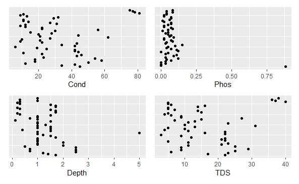

```r
p_cond <- wrangled_crabs %>%
  ggplot(aes(y = row_order)) +
  geom_point(aes(x =Cond)) +
  theme(axis.title.y = element_blank(),
        axis.text.y = element_blank(),
        axis.ticks.y = element_blank())

p_phos <- wrangled_crabs %>%
  ggplot(aes(y = row_order)) +
  geom_point(aes(x = Phos)) +
  theme(axis.title.y = element_blank(),
        axis.text.y = element_blank(),
        axis.ticks.y = element_blank())

p_depth <- wrangled_crabs %>%
  ggplot(aes(y = row_order)) +
  geom_point(aes(x = Depth)) +
  theme(axis.title.y = element_blank(),
        axis.text.y = element_blank(),
        axis.ticks.y = element_blank())

p_tds <- wrangled_crabs %>%
  ggplot(aes(y = row_order)) +
  geom_point(aes(x = TDS)) +
  theme(axis.title.y = element_blank(),
        axis.text.y = element_blank(),
        axis.ticks.y = element_blank())

p_cond + p_phos + p_depth + p_tds
```

# Looking at the cleveland plot we can seee that there are four points outside the bound of the cond data. These are not extremely out of order, and look to be within a standard range.

# For the Phos cleveland plot we can see one point FAR outside of the range of the other points. Most of the points are below values of ~0.125, but there is a point beyond 0.8. This would be extremelyf ar outside of standard error.

# For the Depth plot we can see 1 point that is at 5, whereas most points are bound by 2. This is seems significant eno ugh to be an outlier, but is not as far as the phosphorous point.

# For TDS tere are four points out in the top right corner, similar to the COnd graph. These values are large, but not singificant enought o be an outlier.

## Histograms

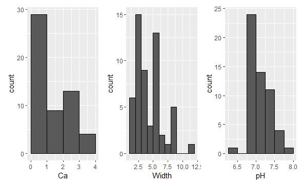

```r
h_width <- wrangled_crabs %>%
  ggplot() +
  geom_histogram(aes(x = Width),
                 binwidth = 1,
                 boundary = 0,
                 closed = "right",
                 color = "black")

h_ph <- wrangled_crabs %>%
  ggplot()+
  geom_histogram(aes(x=pH),
                 binwidth = 0.25,
                 boundary=0,
                 closed="right",
                 color="black")

h_ca <- wrangled_crabs %>%
  ggplot()+
  geom_histogram(aes(x=Ca),
                 binwidth = 1,
                 boundary=0,
                 closed="right",
                 color="black")
h_ca + h_width + h_ph
```

# For the Ca graph there is nothing notable, all the data is within a very close range. There are a few smaller values between 3.5 and 4, but nowere close to being an outlier.

# On the width column there is one point of ~11 that could potentially be an outlier. There are values of 9 as well, so it is not very far out. Compared to some of the other data columns, this is not significant enough to be an outlier.

# There are a few data points that are out of the average, one high and one low, but nothing special. All of the data seeems to be within a quartile range of each other.

## Density Plots

```r
d_width <- wrangled_crabs %>%
  ggplot()+
  geom_density(aes(x = Width))

d_ph <- wrangled_crabs %>%
  ggplot()+
  geom_density(aes(x = pH))

d_ca <- wrangled_crabs %>%
  ggplot()+
  geom_density(aes(x = Ca))

d_width + d_ph + d_ca
```

[output not shown]

# The density plots look very similar to the histograms. These give us a more clear view of the trends of the data points. Looking at this we can for sure see that non eof these data points are that far out of the average range.

## Patchwork: Histogram + Density Plot

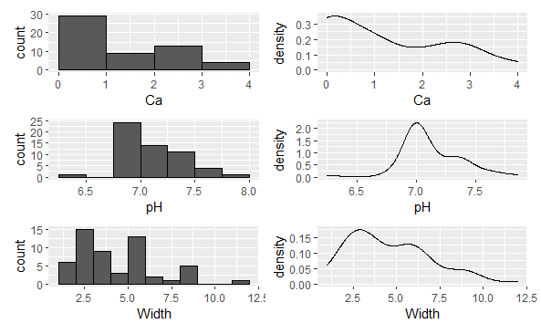

```r
h_ca + d_ca + h_ph + d_ph + h_width + d_width + plot_layout(ncol = 2, nrow = 3)
```

# The pathwork provides a clear comparison between the histograms and density plots. This helps to compare the two side by side, but the data within it is still the same as what could be extrapolated above.

## GGpairs

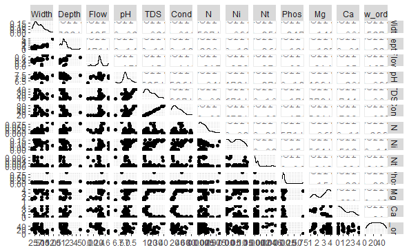

```r
ggpairs(wrangled_crabs)
```

# The ggpairs argument is interesting in how it shows us the correlation between different vairables. We can see a few trends such as the highcorrelation between Cond and TDS, as well as Width to Depth.